# 326.212 Homework 2

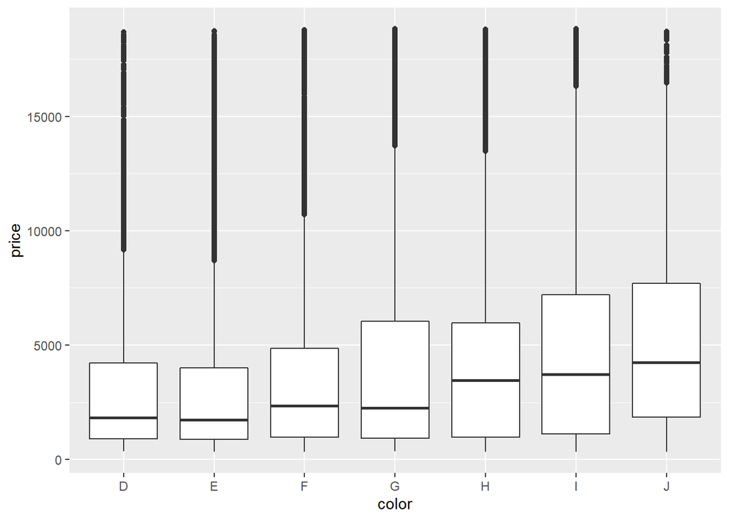

```r
ggplot(data= diamonds)+
  geom_boxplot(mapping = aes(x=color, y= price))
```

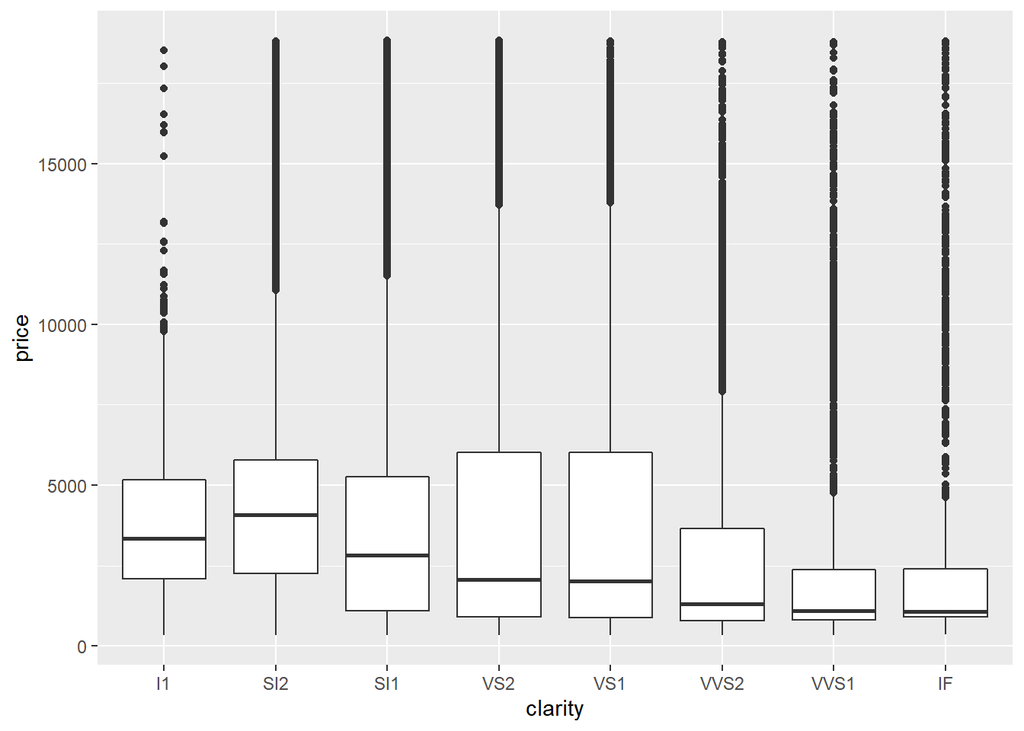

```r
ggplot(data= diamonds)+
  geom_boxplot(mapping = aes(x=clarity, y= price))
```

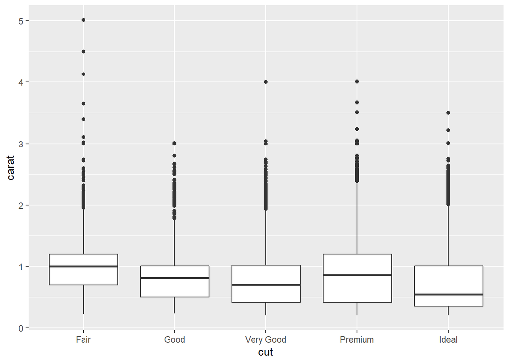

```r
ggplot(data= diamonds)+
  geom_boxplot(mapping = aes(x=cut, y= carat))
```

### Textbook 7.5.2.1

#### Problem 2. Use geom_tile() together with dplyr to explore how average flight delays vary by destination and month of year. What makes the plot difficult to read? How could you improve it?

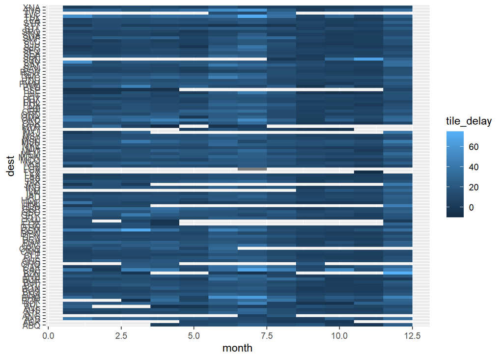

```r
flights%>%group_by(month,dest)%>%summarise(tile_delay= mean(dep_delay, na.rm = T))%>%ggplot(mapping= aes(x=month, y= dest))+geom_tile(mapping= aes(fill=tile_delay))#before
```

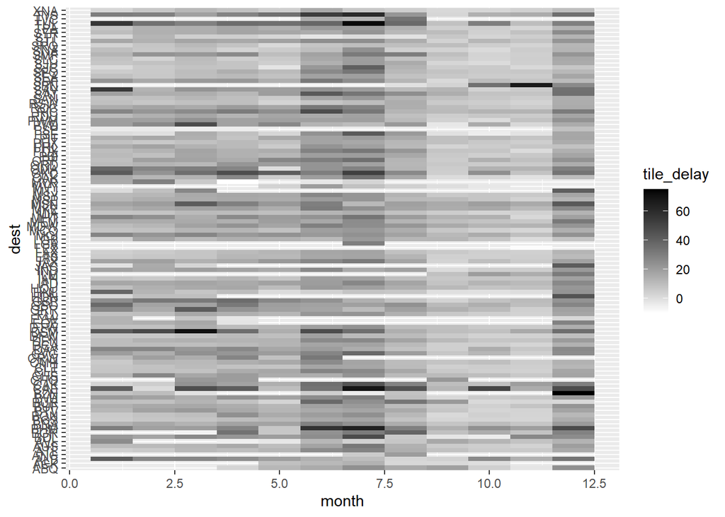

```r
flights%>%group_by(month,dest)%>%summarise(tile_delay= mean(dep_delay, na.rm = T))%>%ggplot(mapping= aes(x=month, y= dest), width = 1)+geom_tile(mapping= aes(fill=tile_delay)) +scale_fill_gradient(low = "white", high = "black")#after
```

`dest`가 매우 많은 반면에 색상간의 차이가 크지 않아 뚜렷하게 구분되지 않아 읽기 어렵다. `scale_fill_gradient`를 이용해서 보다 색변화를 주려한다. 그리고 달 구분도 헷갈렸는데 `ggplot`에 `width = 1`을 넣어 보다 보기 쉽게 만들었다.

### Textbook 7.5.3.1

#### Problem 5.Two dimensional plots reveal outliers that are not visible in one dimensional plots. For example, some points in the plot below have an unusual combination of x and y values, which makes the points outliers even though their x and y values appear normal when examined separately. Why is a scatterplot a better display than a binned plot for this case?

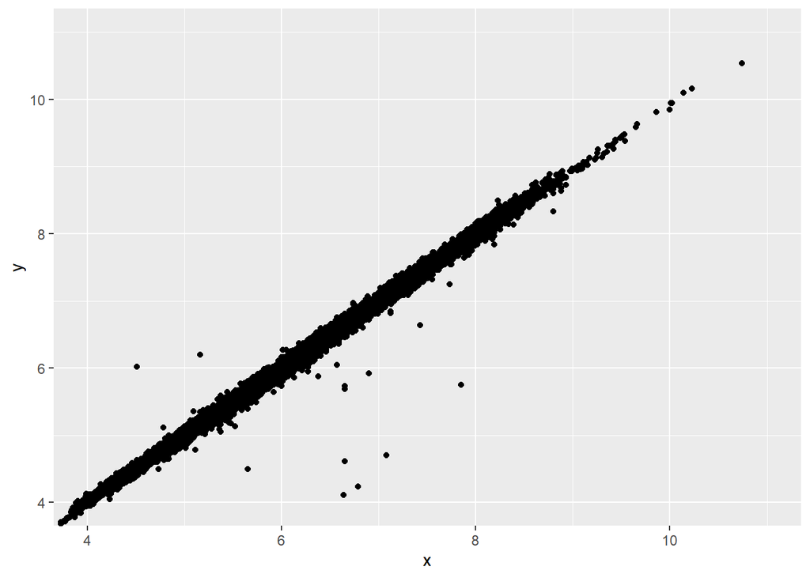

```r
ggplot(data = diamonds) +
  geom_point(mapping = aes(x = x, y = y)) +
  coord_cartesian(xlim = c(4, 11), ylim = c(4, 11))
```

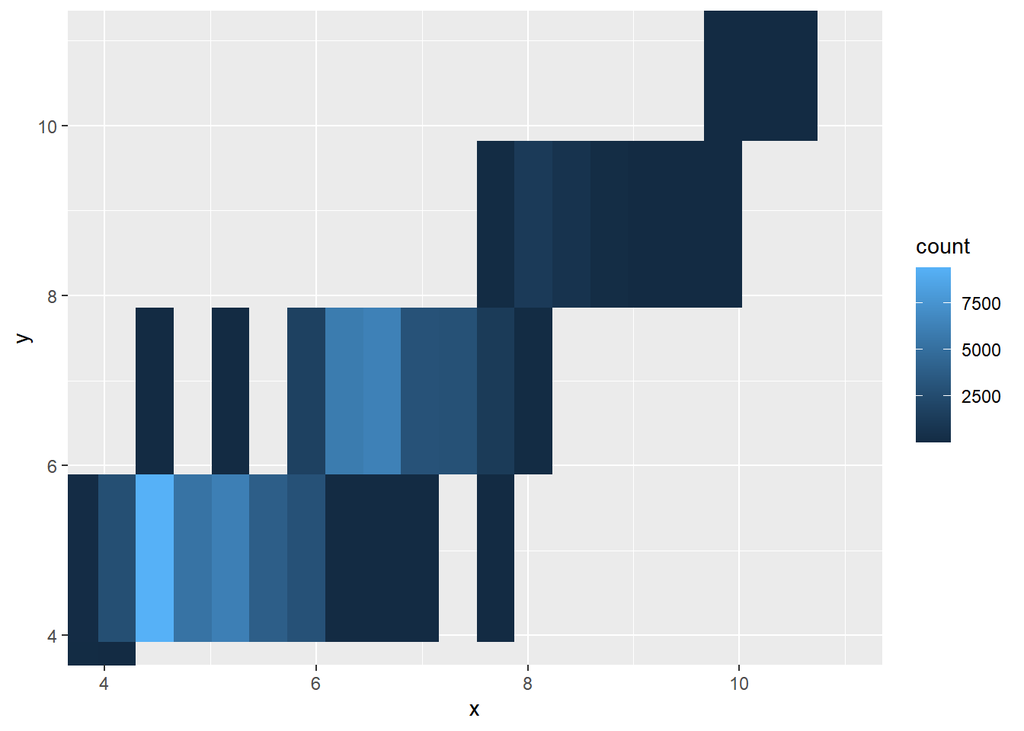

```r
ggplot(data = diamonds) +
  geom_bin2d(mapping = aes(x = x, y = y))+
coord_cartesian(xlim = c(4, 11), ylim = c(4, 11))
```

binned plot의 경우 연속형 변수가 범주형 변수처럼 작동하는 모습이 나타나고, 이에 어떤 bin 범위에서 1개만 value가 존재하더라도 그 부분이 다 색이 칠해지므로 이상점이 나타나는 것을 scatterplot에서보다 확인하기 어렵다.

### Textbook 10.5

#### Problem 4.Practice referring to non-syntactic names in the following data frame by: Extracting the variable called 1. Plotting a scatterplot of 1 vs 2. Creating a new column called 3 which is 2 divided by 1. Renaming the columns to one, two and three.

```r
annoying <- tibble(
  `1` = 1:10,
  `2` = `1` * 2 + rnorm(length(`1`))
)
annoying$`1` # Q.1
```

```
##  [1]  1  2  3  4  5  6  7  8  9 10
```

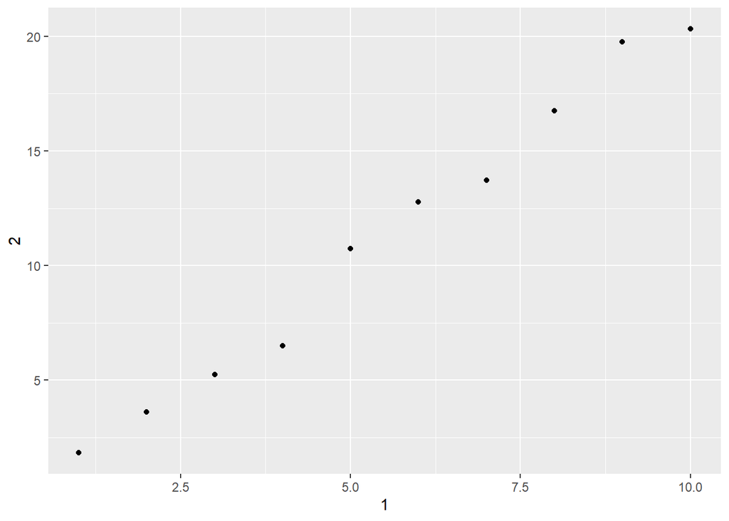

```r
ggplot(data=annoying)+
  geom_point(mapping=aes(x=`1`,y=`2`)) # Q.2
```

```r
mutate(annoying, `3` = `2` / `1`)#Q.3
```

```
## # A tibble: 10 x 3
##      `1`   `2`   `3`
##    <int> <dbl> <dbl>
##  1     1  1.83  1.83
##  2     2  3.63  1.81
##  3     3  5.25  1.75
##  4     4  6.51  1.63
##  5     5 10.7   2.15
##  6     6 12.8   2.13
##  7     7 13.7   1.96
##  8     8 16.7   2.09
##  9     9 19.8   2.20
## 10    10 20.3   2.03
```

```r
mutate(annoying, `3` = `2` / `1`)%>%rename( one=`1`, two=`2`,three=`3`)#Q.4
```

```
## # A tibble: 10 x 3
##      one   two three
##    <int> <dbl> <dbl>
##  1     1  1.83  1.83
##  2     2  3.63  1.81
##  3     3  5.25  1.75
##  4     4  6.51  1.63
##  5     5 10.7   2.15
##  6     6 12.8   2.13
##  7     7 13.7   1.96
##  8     8 16.7   2.09
##  9     9 19.8   2.20
## 10    10 20.3   2.03
```

### Textbook 11.2.2

#### Problem 5.Identify what is wrong with each of the following inline CSV files. What happens when you run the code?

```r
read_csv("a,b\n1,2,3\n4,5,6")
```

```
## # A tibble: 2 x 2
##       a     b
##   <dbl> <dbl>
## 1     1     2
## 2     4     5
```

```r
read_csv("a,b,c\n1,2\n1,2,3,4")
```

```
## # A tibble: 2 x 3
##       a     b     c
##   <dbl> <dbl> <dbl>
## 1     1     2    NA
## 2     1     2     3
```

```r
read_csv("a,b\n\"1")
```

```
## # A tibble: 1 x 2
##       a b
##   <dbl> <chr>
## 1     1 <NA>
```

```r
read_csv("a,b\n1,2\na,b")
```

```
## # A tibble: 2 x 2
##   a     b
##   <chr> <chr>
## 1 1     2
## 2 a     b
```

```r
read_csv("a;b\n1;3")
```

```
## # A tibble: 1 x 1
##   `a;b`
##   <chr>
## 1 1;3
```

첫번째 코드는 가장 첫째 줄인 열의 이름이 2개 밖에 없다. 이와달리 value는 열이 3개가 필요하다. 그래서 코드를 실행하면 3과 6이 담기지 않는다.

두번째 코드는 가장 첫째 줄인 열의 이름이 3개이지만 value는 윗 행이 2개 아래 행이 4개다. 그래서 코드를 실행하면 윗행에서 value하나가 NA로 나타나고, 아래행에서는 4가 담기지 못한다.

세번째 코드는 `"`가 완성된 형태가 아니다. 그래서 코드를 실행하면 1앞의 `"`는 사라지고 1만 남으며, b열의 value는 NA가 된다.

네번째 코드는 두번째 행의 a,b는 문자다. 그래서 코드를 실행하면 두번째 행으로 인해 1,2가 있음에도 전체 열이 문자열로 강제된다.

다섯번째 코드는 `read_csv()`에서는 `,`를 써야지 구분이 되는데 `;`를 써버렸다. 그래서 코드를 실행하면 `a;b`,`1;3`이 한 묶음으로 나온다.

### Textbook 11.3.5

#### Problem 4.If you live outside the US, create a new locale object that encapsulates the settings for the types of file you read most commonly.

```r
kor_locale<-locale(date_names= "ko",date_format = "%Y/%m/%d ", time_format = "%p %I:%M:%S")
```

대한민국은 날짜는 2020/10/13일 꼴로 쓰고, 시간 포맷은 오후 11:59:59로 쓴다.

#### Problem 7.Generate the correct format string to parse each of the following dates and times:

```r
d1 <- "January 1, 2010"
d2 <- "2015-Mar-07"
d3 <- "06-Jun-2017"
d4 <- c("August 19 (2015)", "July 1 (2015)")
d5 <- "12/30/14" # Dec 30, 2014
t1 <- "1705"
t2 <- "11:15:10.12 PM"
parse_date(d1, "%B %d, %Y")
```

```
## [1] "2010-01-01"
```

```r
parse_date(d2, "%Y- %b -%d")
```

```
## [1] "2015-03-07"
```

```r
parse_date(d3, "%d- %b -%Y")
```

```
## [1] "2017-06-06"
```

```r
parse_date(d4, "%B %d (%Y)")
```

```
## [1] "2015-08-19" "2015-07-01"
```

```r
parse_date(d5, "%m/%d/%y")
```

```
## [1] "2014-12-30"
```

```r
parse_time(t1, "%H%M")
```

```
## 17:05:00
```

```r
parse_time(t2, "%I:%M:%OS %p")
```

```
## 23:15:10.12
```

### Extra Questions

#### Problem 1.a

```r
library("quantmod")
options("getSymbols.warning4.0"=FALSE) # to suppress warnings
samsung <- getSymbols("005930.KS", auto.assign=FALSE)  # KOSPI tick number is 005930
head(samsung)
```

```
##            005930.KS.Open 005930.KS.High 005930.KS.Low 005930.KS.Close
## 2007-01-02          12400          12540         12320           12520
## 2007-01-03          12540          12560         12220           12280
## 2007-01-04          12220          12240         12060           12120
## 2007-01-05          12160          12180         11900           11900
## 2007-01-08          11840          11880         11580           11680
## 2007-01-09          11740          11880         11640           11720
##            005930.KS.Volume 005930.KS.Adjusted
## 2007-01-02         17607300           0.329870
## 2007-01-03         19676500           0.323546
## 2007-01-04         18258900           0.319331
## 2007-01-05         28400400           0.313534
## 2007-01-08         33081550           0.307738
## 2007-01-09         20109850           0.308792
```

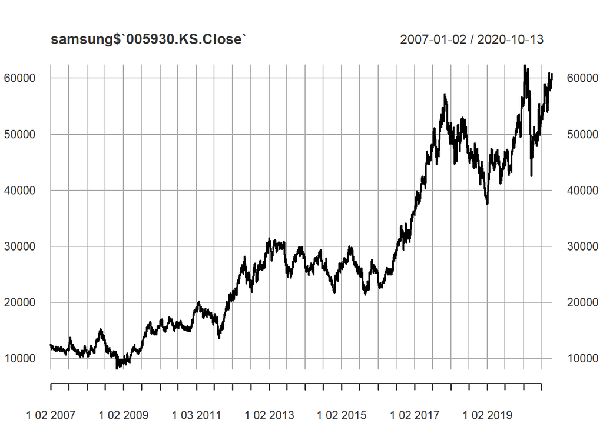

```r
plot(samsung$`005930.KS.Close`)
```

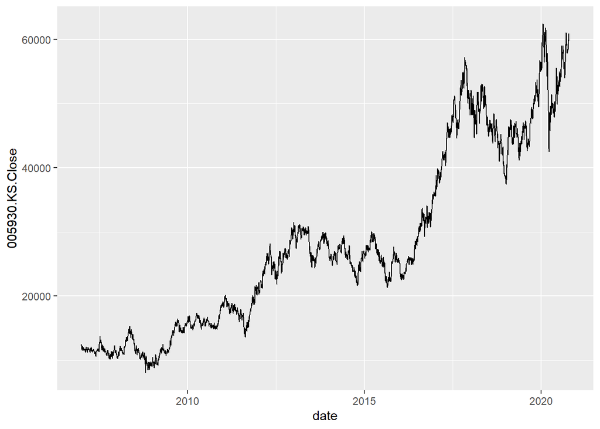

```r
new_samsung<-as_tibble(samsung, rownames=NA)
new_date<-as.Date(rownames(new_samsung),"%Y-%m-%d")
mutate(new_samsung, date = new_date )%>%ggplot()+
  geom_line(mapping = aes(x=date, y=`005930.KS.Close`))
```

`rownames=NA`를 이용해 tibble 과정에서 사라지는 행 이름을 보존하고 `as.date`를 가지고 단지 행 이름뿐이었던 것들을 날짜취급하게 만든다. 그리고 이것들을 새롭게 열에 추가해준다. 그 뒤는 `ggplot`을 이용해 x축에는 새로 만든 `date`, y축에는 주가가 오게 그래프를 그려내면 된다.

#### Problem 1.b

```r
library(quantmod)
getFX('USD/KRW', from = Sys.Date() - 179, to = Sys.Date())
```

```
## [1] "USD/KRW"
```

```r
getFX('JPY/KRW', from = Sys.Date() - 179, to = Sys.Date())
```

```
## [1] "JPY/KRW"
```

```r
new_usdkrw<-as.tibble(USDKRW, rownames = NA)
```

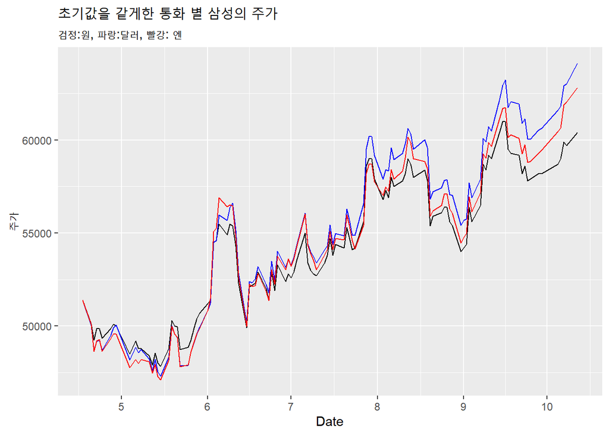

```r
new_date2<-as.Date(rownames(new_usdkrw),"%Y-%m-%d")
new_usdkrw2<-mutate(new_usdkrw, date1 =new_date2) #원달러 자료 tibble 이후 date1 열 생성

new_jpykrw<-as.tibble(JPYKRW, rownames = NA)
new_date3<-as.Date(rownames(new_jpykrw),"%Y-%m-%d")
new_jpykrw2<-mutate(new_jpykrw, date2 =new_date3) #원엔 자료 tibble 이후 date2 열 생성

n_s<-mutate(new_samsung, date = new_date)%>%filter(date %in% new_usdkrw2$date1) # 주식시장 자료 중 원/달러 자료(원/엔화자료)가 있는 날짜만 뽑아냄(시스템 날짜로부터 180일 이내일 것임)

n_u<-new_usdkrw2%>%filter(date1 %in% n_s$date  ) #원/달러 자료 중 주식시장이 열리는 날만 뽑아냄

n_j<-new_jpykrw2%>%filter(date2 %in% n_s$date  ) #원/엔화 자료 중 주식시장이 열리는 날만 뽑아냄

U<-as.numeric(USDKRW[1,])
J<-as.numeric(JPYKRW[1,])
n_s%>%mutate(samsung_usd= n_s$`005930.KS.Close`/n_u$USD.KRW, samsung_jpy =
n_s$`005930.KS.Close`/n_j$JPY.KRW)%>%ggplot()+geom_line(mapping = aes(x=date, y=`005930.KS.Close`))+geom_line(mapping = aes(x=date, y=`samsung_usd`*U), color = "blue")+geom_line(mapping = aes(x=date, y=`samsung_jpy`*J), color = "red")+labs(title="초기값을 같게한 통화 별 삼성의 주가", subtitle = "검정:원, 파랑:달러, 빨강: 엔 ",
        x ="Date", y = "주가") # after normalize
```

먼저, `getFX`를 활용해 최근 180일 이내의 원/달려자료와 원/엔자료를 다운받는다. 그리고 이를 활용해 삼성의 주가를 원화에서 달러와 엔으로 나타내고자하는데, 여기서 문제점은 주식시장은 매일같이 열리는 것이 아니라 주말, 공휴일 등은 쉬므로 원/달러, 원/엔 자료와 주식 자료에서 열의 순서가 같아도 날짜가 다르다는 문제가 발생한다. 이 상태에서 계산이 이루어진다면 오류가 발생할 것이다. 그러므로 세 자료 모두에서 행 순서에 따른 날짜를 동일하게 만들어주는 과정이 필요하다. 나의 경우 `tibble()`을 이용해 환율자료를 정리하고 1.a 문제처럼 사라진 날짜열을 새로 만들어준다. 이제 주식 자료에서 환율자료와 겹치는 날짜만을 뽑아내야하는데 이 때 `filter()` 와 `%in%`을 이용할 수 있었다. 이 과정을 거치면서 주식자료와 환율자료의 date는 같아진다. 이제 세 자료 모두에서 행 순서에 따른 날짜가 모두 같아졌으므로 계산을 진행해주면 된다. 삼성의 종가(원)에 각각 원/달러 환율과 원/엔 환율을 나눠줌으로서 달러로 나타낸 삼성의 종가와 엔으로 나타낸 삼성의 종가를 얻을 수 있다. 세 개의 시계열 그래프를 나타낸 결과 통화의 가치 차이로 인해 좋지 않은 그래프가 나온다. 그러므로 달러, 엔으로 나타낸 주가에 각각 자료 첫 날의 원/달러 환율과 원/엔 환율을 곱해줌으로서 초기값을 같게 만들어 준다. 그러면 첫 지점이 같은 세 그래프가 그려진다.

#### Problem 2.

```r
library(tidyverse)
seoul2019<-read_csv("etc/seoulpopdata.csv")[c(3:27),] #a 25행 10열의 tibble
```

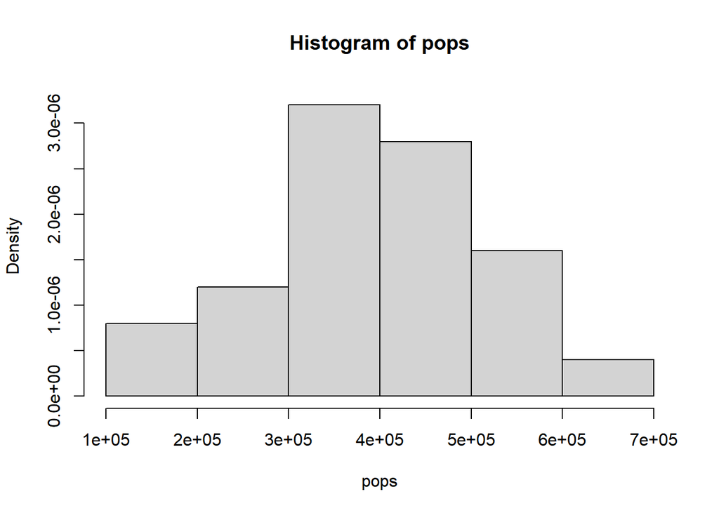

```r
a<-seoul2019[,c(3:10)]
b<-parse_character(seoul2019$`<c7><e0><U+0064><U+00B1><U+00B8><U+00BF><U+00AA><U+00BA><U+00B0>(<U+003E><U+00B8><U+9D7F>)`,locale = locale(encoding = "EUC-KR"))
seoul2019tidy<-cbind(b,a);names(seoul2019tidy)<- c("구","총인구","총인구_남자(명)", "총인구_여자(명)","총인구_성비","내국인(명)","내국인_남자(명)","내국인_여자(명)","내국인_성비") #b

a1<-parse_number(seoul2019tidy$"총인구")
a2<-parse_number(seoul2019tidy$"총인구_남자(명)")
a3<-parse_number(seoul2019tidy$"총인구_여자(명)")
a4<-parse_number(seoul2019tidy$"총인구_성비")
a5<-parse_number(seoul2019tidy$"내국인(명)")
a6<-parse_number(seoul2019tidy$"내국인_남자(명)")
a7<-parse_number(seoul2019tidy$"내국인_여자(명)")
a8<-parse_number(seoul2019tidy$"내국인_성비")
d<-tibble(
        "구" = b,
        "총인구" = a1,
        "총인구_남자(명)" = a2,
        "총인구_여자(명)" = a3,
        "총인구_성비" = a4,
        "내국인(명)" = a5,
        "내국인_남자(명)" = a6,
        "내국인_여자(명)" = a7,
        "내국인_성비" = a8) #c

pops<-d$총인구
hist(pops, freq= F, ylim = c(0,0.0000033), ylab = "Density")
```

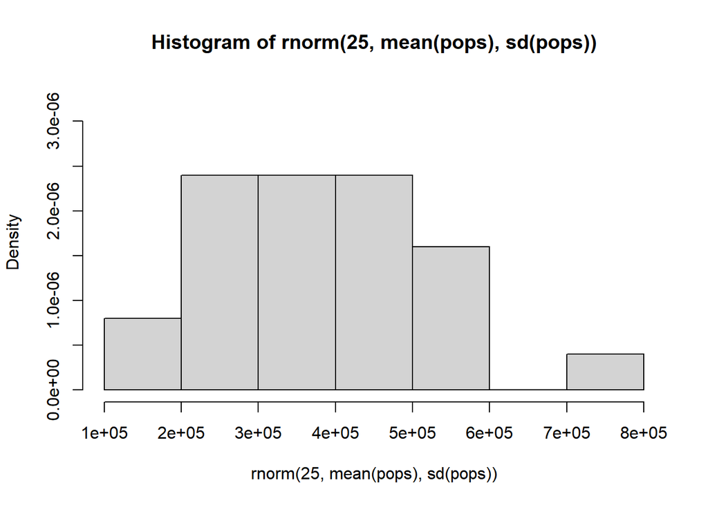

```r
 hist(rnorm(25,  mean(pops),sd(pops)),freq= F, ylim = c(0,0.0000033), ylab = "Density") #d
```

```r
 e<-sample(pops, size = 10, replace = T); f<-sample(pops, size = 10, replace = T)
 mean(e);mean(pops); mean(f);mean(e) #e
```

```
## [1] 418844.1
```

```
## [1] 385581.6
```

```
## [1] 361433.9
```

```
## [1] 418844.1
```

```r
 mean(replicate(100,mean(sample(pops, size = 10, replace = T))))
```

```
## [1] 386736
```

```r
mean(replicate(1000,mean(sample(pops, size = 10, replace = T))))
```

```
## [1] 382910.5
```

```r
mean(replicate(10000,mean(sample(pops, size = 10, replace = T)))) #f
```

```
## [1] 385386.7
```

```r
mean(sample(pops, size = 25, replace = T)); mean(sample(pops, size = 25, replace = T)); mean(pops)
```

```
## [1] 446218.5
```

```
## [1] 366342.4
```

```
## [1] 385581.6
```

```r
mean(sample(pops, size = 100, replace = T)); mean(sample(pops, size = 100, replace = T)); mean(pops) #g
```

```
## [1] 404131
```

```
## [1] 392489.5
```

```
## [1] 385581.6
```

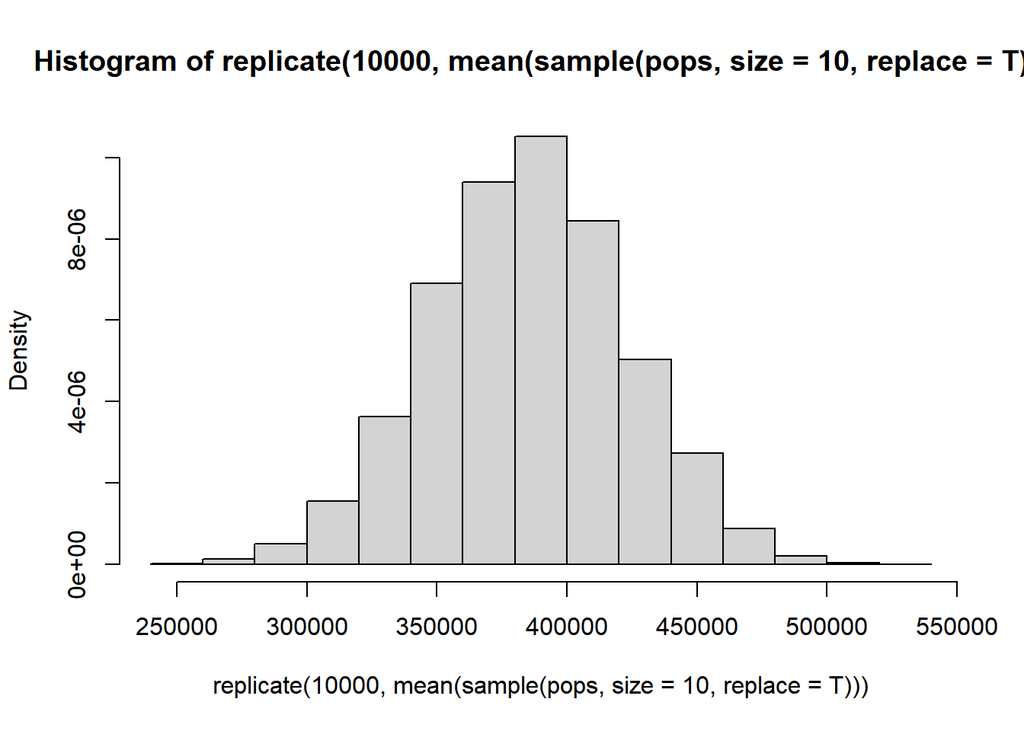

```r
hist(replicate(10000,mean(sample(pops, size = 10, replace = T))), freq = F)
```

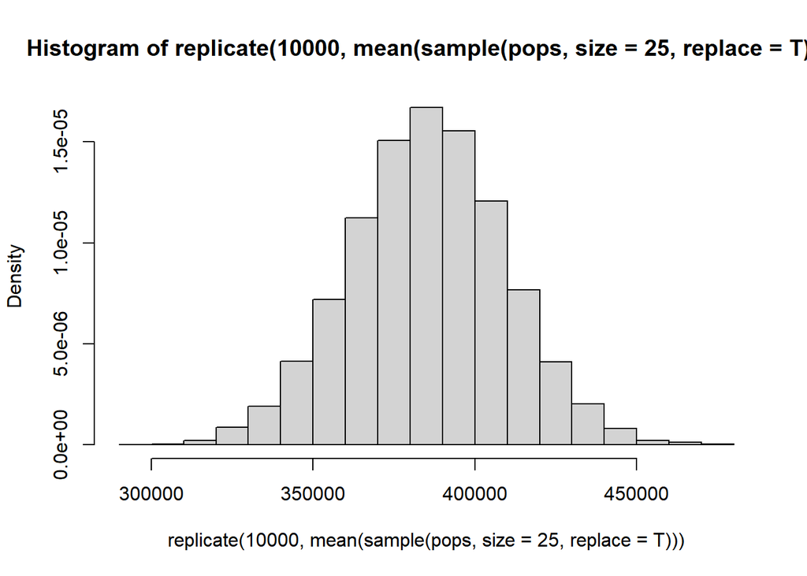

```r
hist(replicate(10000,mean(sample(pops, size = 25, replace = T))), freq = F)
```

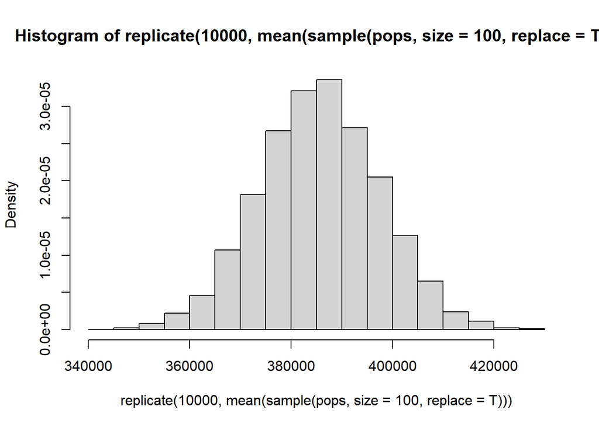

```r
hist(replicate(10000,mean(sample(pops, size = 100, replace = T))), freq = F)#h
```

```r
quantile(replicate(10000,mean(sample(pops, size = 10, replace = T))), probs=seq(0, 1,0.025))#i
```

```
##       0%     2.5%       5%     7.5%      10%    12.5%      15%    17.5%
## 238389.5 309776.9 322048.2 330366.6 336142.9 341398.9 346044.4 349838.0
##      20%    22.5%      25%    27.5%      30%    32.5%      35%    37.5%
## 352937.8 356257.7 359467.4 362679.2 365883.7 368513.0 371202.3 373767.9
##      40%    42.5%      45%    47.5%      50%    52.5%      55%    57.5%
## 376232.4 378803.2 380977.5 383210.9 385533.6 387727.2 390372.3 392728.9
##      60%    62.5%      65%    67.5%      70%    72.5%      75%    77.5%
## 395124.1 397747.3 400303.0 402675.2 405326.5 408170.4 410845.7 413910.5
##      80%    82.5%      85%    87.5%      90%    92.5%      95%    97.5%
## 417438.7 421233.2 425119.4 429288.1 433817.0 439939.9 447642.5 459055.2
##     100%
## 530482.9
```